# Buncombe Jail EJ Length of Stay Misdemeanors for Short Stays

DIH

2024-03-31

## A. Class M stays of 1 day by pre- and post-PTIA contingency tables

Consider only class_type_dom “M” and stays of 1 day. This includes repetitive stays for persons detained more than once.

Total number of stays of 1 day

| which_side | N |
| --- | --- |
| POST | 145 |
| PRE | 733 |

Persons class “M” having at least one stay of 1 day over pre- and post-PTIA intervals.

| which_side | N |
| --- | --- |
| POST | 144 |
| PRE | 672 |

## B. Compare 1 Day Stays to Similar Period One Year Ago

Number of Stays (not persons) Offense M for Stays of 1 Day by Starting Day of Week (Sunday is 1) Compared to Similar Calendar Period 2022-10-01 to 2023-03-15

| day_of_week | N_compare | N_PTIA |
| --- | --- | --- |
| 1 | 14 | 15 |
| 2 | 15 | 25 |
| 3 | 25 | 16 |
| 4 | 28 | 22 |
| 5 | 39 | 28 |
| 6 | 35 | 31 |
| 7 | 22 | 8 |
| (all) | 178 | 145 |

Number of Stays of 1 Day as As Percentages

| day_of_week | pct_compare | pct_PTIA |
| --- | --- | --- |
| 1 | 0.079 | 0.103 |
| 2 | 0.084 | 0.172 |
| 3 | 0.140 | 0.110 |
| 4 | 0.157 | 0.152 |
| 5 | 0.219 | 0.193 |
| 6 | 0.197 | 0.214 |
| 7 | 0.124 | 0.055 |

## C. All Class M with stays between 2 and 4 days contingency tables

Consider only class_type_dom “M” and stays of 2 to 4 days.

Number of stays between 2 and 4 days

| which_side | N |
| --- | --- |
| POST | 125 |
| PRE | 647 |

Number of persons having stays between 2 and 4 days:

| which_side | N |
| --- | --- |
| POST | 122 |
| PRE | 545 |

## D. Compare 2 to 4 Day Stays to Similar Period One Year Ago

Number of Stays (not persons) Offense M for Between 2 and 4 Days by Starting Day of Week (Sunday is 1) Compared on Similar Calendar Period 2022-10-01 to 2023-03-15

| day_of_week | N_compare | N_PTIA |
| --- | --- | --- |
| 1 | 38 | 29 |
| 2 | 13 | 14 |
| 3 | 20 | 12 |
| 4 | 21 | 14 |
| 5 | 21 | 7 |
| 6 | 19 | 8 |
| 7 | 25 | 41 |
| (all) | 157 | 125 |

Number of Stays (between 2 and 4 days) as As Percentages

| day_of_week | pct_compare | pct_PTIA |
| --- | --- | --- |
| 1 | 0.242 | 0.232 |
| 2 | 0.083 | 0.112 |
| 3 | 0.127 | 0.096 |
| 4 | 0.134 | 0.112 |
| 5 | 0.134 | 0.056 |
| 6 | 0.121 | 0.064 |
| 7 | 0.159 | 0.328 |

## E. Percent Line Plots

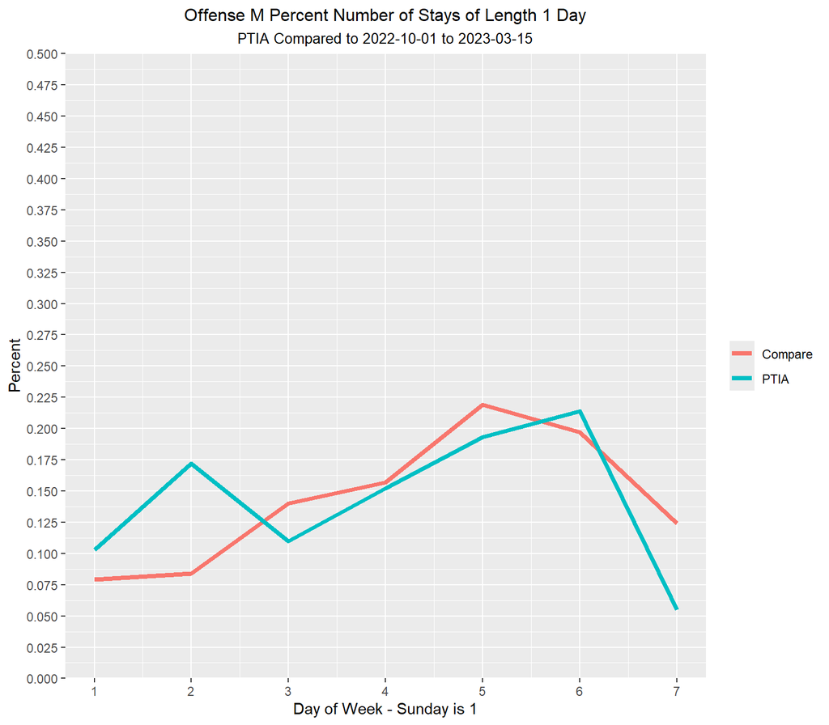

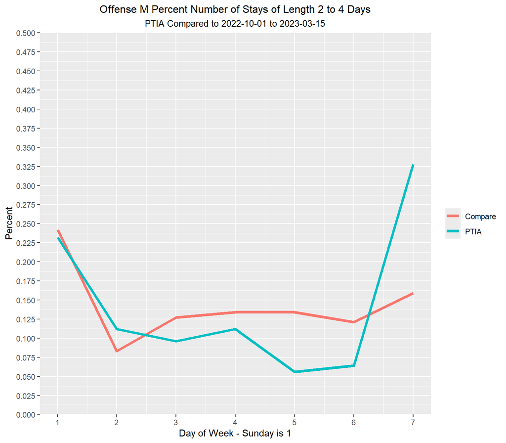